# AlphaDIA_analysis

Muskan Kumari(Team1)

2026-07-05

##1.Introduction

This report describes the processing and statistical analysis of DIA proteomics data generated using AlphaDIA. The workflow includes missing value assessment, imputation, normalization, batch correction, quality control, differential expression analysis, and functional enrichment.

##2.Load libraries

```r
library(SummarizedExperiment)
library(QFeatures)
library(limma)
```

```r
library(ggplot2)
library(sva)
library(clusterProfiler)
library(org.Hs.eg.db)
library(ReactomePA)
library(pheatmap)
library(data.table)
library(writexl)
```

##3.Load SummarizedExperiment object

```r
setwd("Z:/Muskan/Documents/Helsinki/hel_fin_doc/PhD_courses/pc/capstoneProject/alphadia")

se <- readRDS("protein_SE.rds")

assay(se)[assay(se)==0] <- NA
sum(is.na(assay(se)))
```

```
## [1] 14362
```

The protein abundance matrix was imported and zero values were converted back to missing values (NA), since zeros represented proteins that were not detected rather than true zero abundance.

##4.Missing value assesment Missing values per sample

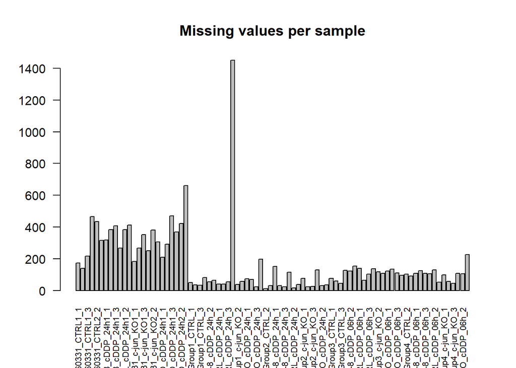

```r
sample_na <- colSums(is.na(assay(se)))

barplot(
  sample_na,
  las=2,
  cex.names=0.7,
  main="Missing values per sample"
)
```

##Missing values per protein

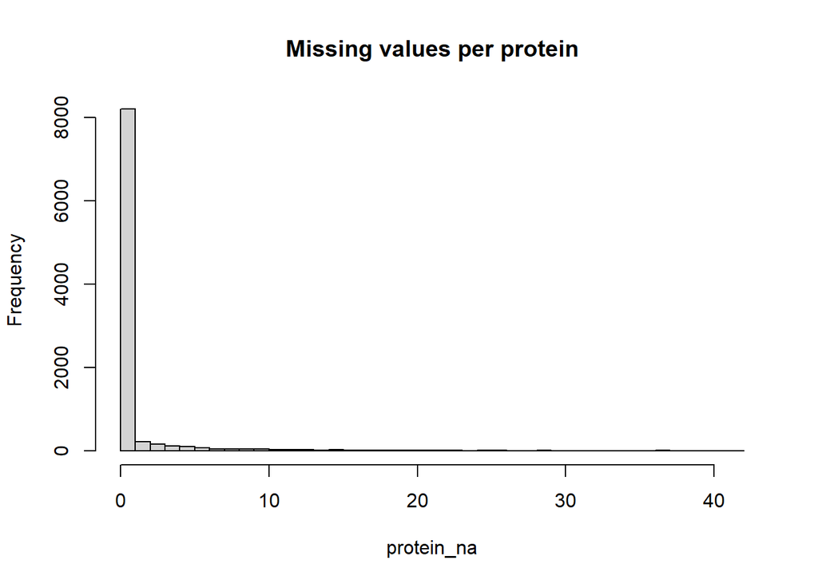

```r
protein_na <- rowSums(is.na(assay(se)))

hist(protein_na,
     breaks=50,
     main="Missing values per protein")
```

```r
#Proteins containing missing values in more than 50% of samples were removed.
keep <- protein_na <= (0.5*ncol(se))
se <- se[keep,]
```

##5.Missing value imputation

Three imputation methods were compared.

```r
#KNN
se_knn <- impute(se,method="knn")
```

```
## Imputing along margin 1 (features/rows).
```

[output not shown]

```r
#MinDet
se_mindet <- impute(se,method="MinDet")
```

```
## Imputing along margin 2 (samples/columns).
```

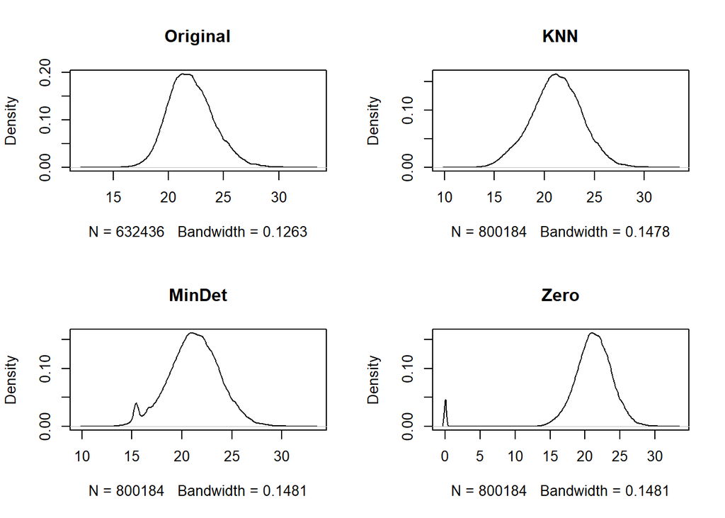

```r
#Zero
se_zero <- impute(se,method="zero")
par(mfrow=c(2,2))

plot(density(na.omit(assay(se))),
     main="Original")

plot(density(na.omit(assay(se_knn))),
     main="KNN")

plot(density(na.omit(assay(se_mindet))),
     main="MinDet")

plot(density(na.omit(assay(se_zero))),
     main="Zero")
```

KNN imputation was selected because it best preserved the original intensity distribution.

##6.Quantile normalization

```r
expr_norm <- normalizeBetweenArrays(
    assay(se_knn),
    method="quantile"
)

assay(se_knn) <- expr_norm
#The normalized dataset was saved for downstream analyses.

saveRDS(se_knn,
        "protein_SE_knn_normalized.rds")
```

##7.Principal Component Analysis before batch correction

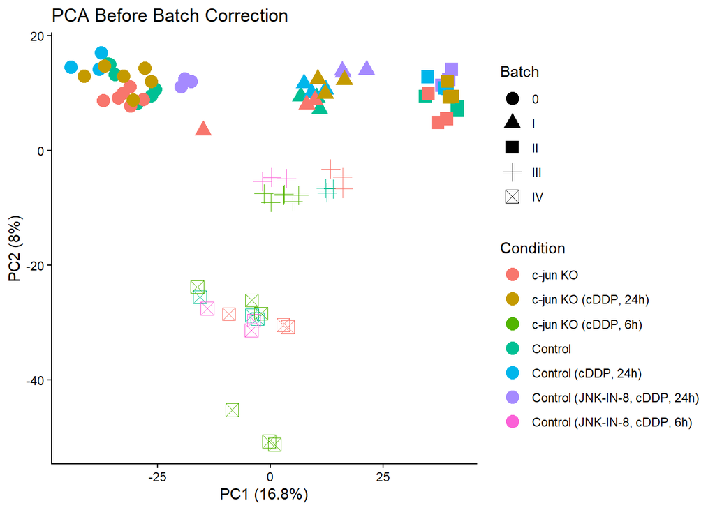

```r
library(ggrepel)
set.seed(456)
expr <- assay(se_knn)

pca_before <- prcomp(
  t(expr),
  center = TRUE,
  scale. = FALSE
)

percentVar <- round(
  100 * pca_before$sdev^2 / sum(pca_before$sdev^2),
  1
)

pca_before_df <- data.frame(
  Sample = colnames(expr),
  PC1 = pca_before$x[,1],
  PC2 = pca_before$x[,2],
  Condition = colData(se_knn)$condition,
  Batch = colData(se_knn)$batch
)

p_before <- ggplot(
  pca_before_df,
  aes(
    PC1,
    PC2,
    color = Condition,
    shape = Batch
  )
) +
  geom_point(size = 4) +
  xlab(paste0("PC1 (", percentVar[1], "%)")) +
  ylab(paste0("PC2 (", percentVar[2], "%)")) +
  ggtitle("PCA Before Batch Correction") +
  theme_classic()

print(p_before)
```

##8.Batch correction using ComBat

```r
se_batch <- se_knn

expr_batch <- ComBat(
  dat = assay(se_batch),
  batch = colData(se_batch)$batch,
  par.prior = TRUE,
  prior.plots = FALSE
)
```

```
## Found5batches
```

```
## Adjusting for0covariate(s) or covariate level(s)
```

```
## Standardizing Data across genes
```

```
## Fitting L/S model and finding priors
```

```
## Finding parametric adjustments
```

```
## Adjusting the Data
```

```r
assay(se_batch) <- expr_batch

saveRDS(
  se_batch,
  "protein_SE_knn_batchcorrected.rds"
)
```

##9.PCA after batch correction

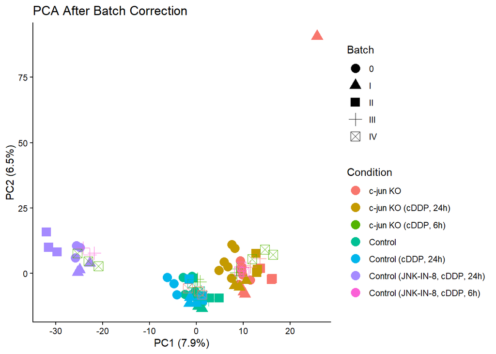

```r
expr <- assay(se_batch)

pca_after <- prcomp(
  t(expr),
  center = TRUE,
  scale. = FALSE
)

percentVar <- round(
  100 * pca_after$sdev^2 / sum(pca_after$sdev^2),
  1
)

pca_after_df <- data.frame(
  Sample = colnames(expr),
  PC1 = pca_after$x[,1],
  PC2 = pca_after$x[,2],
  Condition = colData(se_batch)$condition,
  Batch = colData(se_batch)$batch
)

p_after <- ggplot(
  pca_after_df,
  aes(
    PC1,
    PC2,
    color = Condition,
    shape = Batch
  )
) +
  geom_point(size = 4) +
  xlab(paste0("PC1 (", percentVar[1], "%)")) +
  ylab(paste0("PC2 (", percentVar[2], "%)")) +
  ggtitle("PCA After Batch Correction") +
  theme_classic()

print(p_after)
```

##10. Outlier assessment

```r
pca_after_df$Distance <- sqrt(
  pca_after_df$PC1^2 +
    pca_after_df$PC2^2
)

outlier <- pca_after_df[
  which.max(pca_after_df$Distance),
]

outlier
```

```
##                              Sample      PC1      PC2 Condition Batch Distance
## Group1_c-jun_KO_1 Group1_c-jun_KO_1 25.71557 90.63446  c-jun KO     I 94.21198
```

```r
sample_missing <- data.frame(
  Sample = colnames(se_batch),
  Missing = colSums(is.na(assay(se_batch)))
)

sample_missing
```

```
##                                                                Sample Missing
## 20260331_CTRL1_1                                     20260331_CTRL1_1       0
## 20260331_CTRL1_2                                     20260331_CTRL1_2       0
## 20260331_CTRL1_3                                     20260331_CTRL1_3       0
## 20260331_CTRL2_1                                     20260331_CTRL2_1       0
## 20260331_CTRL2_2                                     20260331_CTRL2_2       0
## 20260331_CTRL2_3                                     20260331_CTRL2_3       0
## 20260331_CTRL_JNK-IN-8_cDDP_24h1_1 20260331_CTRL_JNK-IN-8_cDDP_24h1_1       0
## 20260331_CTRL_JNK-IN-8_cDDP_24h1_2 20260331_CTRL_JNK-IN-8_cDDP_24h1_2       0
## 20260331_CTRL_JNK-IN-8_cDDP_24h1_3 20260331_CTRL_JNK-IN-8_cDDP_24h1_3       0
## 20260331_CTRL_cDDP_24h1_1                   20260331_CTRL_cDDP_24h1_1       0
## 20260331_CTRL_cDDP_24h1_2                   20260331_CTRL_cDDP_24h1_2       0
## 20260331_CTRL_cDDP_24h1_3                   20260331_CTRL_cDDP_24h1_3       0
## 20260331_c-jun_KO1_1                             20260331_c-jun_KO1_1       0
## 20260331_c-jun_KO1_2                             20260331_c-jun_KO1_2       0
## 20260331_c-jun_KO1_3                             20260331_c-jun_KO1_3       0
## 20260331_c-jun_KO2_1                             20260331_c-jun_KO2_1       0
## 20260331_c-jun_KO2_2                             20260331_c-jun_KO2_2       0
## 20260331_c-jun_KO2_3                             20260331_c-jun_KO2_3       0
## 20260331_c-jun_KO_cDDP_24h1_1           20260331_c-jun_KO_cDDP_24h1_1       0
## 20260331_c-jun_KO_cDDP_24h1_2           20260331_c-jun_KO_cDDP_24h1_2       0
## 20260331_c-jun_KO_cDDP_24h1_3           20260331_c-jun_KO_cDDP_24h1_3       0
## 20260331_c-jun_KO_cDDP_24h2_1           20260331_c-jun_KO_cDDP_24h2_1       0
## 20260331_c-jun_KO_cDDP_24h2_2           20260331_c-jun_KO_cDDP_24h2_2       0
## 20260331_c-jun_KO_cDDP_24h2_3           20260331_c-jun_KO_cDDP_24h2_3       0
## Group1_CTRL_1                                           Group1_CTRL_1       0
## Group1_CTRL_2                                           Group1_CTRL_2       0
## Group1_CTRL_3                                           Group1_CTRL_3       0
## Group1_CTRL_JNK-IN-8_cDDP_24h_1       Group1_CTRL_JNK-IN-8_cDDP_24h_1       0
## Group1_CTRL_JNK-IN-8_cDDP_24h_2       Group1_CTRL_JNK-IN-8_cDDP_24h_2       0
## Group1_CTRL_JNK-IN-8_cDDP_24h_3       Group1_CTRL_JNK-IN-8_cDDP_24h_3       0
## Group1_CTRL_cDDP_24h_1                         Group1_CTRL_cDDP_24h_1       0
## Group1_CTRL_cDDP_24h_2                         Group1_CTRL_cDDP_24h_2       0
## Group1_CTRL_cDDP_24h_3                         Group1_CTRL_cDDP_24h_3       0
## Group1_c-jun_KO_1                                   Group1_c-jun_KO_1       0
## Group1_c-jun_KO_2                                   Group1_c-jun_KO_2       0
## Group1_c-jun_KO_3                                   Group1_c-jun_KO_3       0
## Group1_c-jun_KO_cDDP_24h_1                 Group1_c-jun_KO_cDDP_24h_1       0
## Group1_c-jun_KO_cDDP_24h_2                 Group1_c-jun_KO_cDDP_24h_2       0
## Group1_c-jun_KO_cDDP_24h_3                 Group1_c-jun_KO_cDDP_24h_3       0
```

[output cut: 30 more lines]

```
## Group4_CTRL_1                                           Group4_CTRL_1       0
## Group4_CTRL_2                                           Group4_CTRL_2       0
## Group4_CTRL_3                                           Group4_CTRL_3       0
## Group4_CTRL_JNK-IN-8_cDDP_06h_1       Group4_CTRL_JNK-IN-8_cDDP_06h_1       0
## Group4_CTRL_JNK-IN-8_cDDP_06h_2       Group4_CTRL_JNK-IN-8_cDDP_06h_2       0
## Group4_CTRL_JNK-IN-8_cDDP_06h_3       Group4_CTRL_JNK-IN-8_cDDP_06h_3       0
## Group4_CTRL_cDDP_06h_1                         Group4_CTRL_cDDP_06h_1       0
## Group4_CTRL_cDDP_06h_2                         Group4_CTRL_cDDP_06h_2       0
## Group4_CTRL_cDDP_06h_3                         Group4_CTRL_cDDP_06h_3       0
## Group4_c-jun_KO_1                                   Group4_c-jun_KO_1       0
## Group4_c-jun_KO_2                                   Group4_c-jun_KO_2       0
## Group4_c-jun_KO_3                                   Group4_c-jun_KO_3       0
## Group4_c-jun_KO_cDDP_06h_1                 Group4_c-jun_KO_cDDP_06h_1       0
## Group4_c-jun_KO_cDDP_06h_2                 Group4_c-jun_KO_cDDP_06h_2       0
## Group4_c-jun_KO_cDDP_06h_3                 Group4_c-jun_KO_cDDP_06h_3       0
```

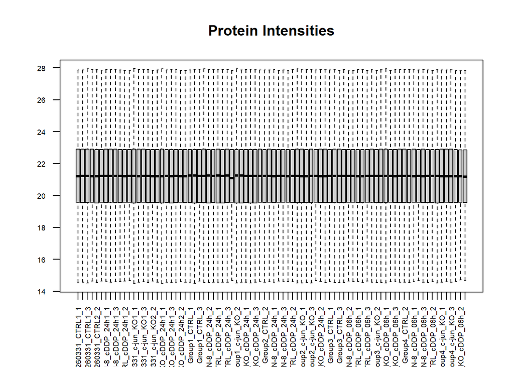

```r
#Boxplot
boxplot(
  assay(se_batch),
  las = 2,
  outline = FALSE,
  cex.axis = 0.6,
  main = "Protein Intensities"
)
```

[figure not shown]

```r
#Density plot
plotDensities(
  assay(se_batch),
  main = "Density Plot"
)
```

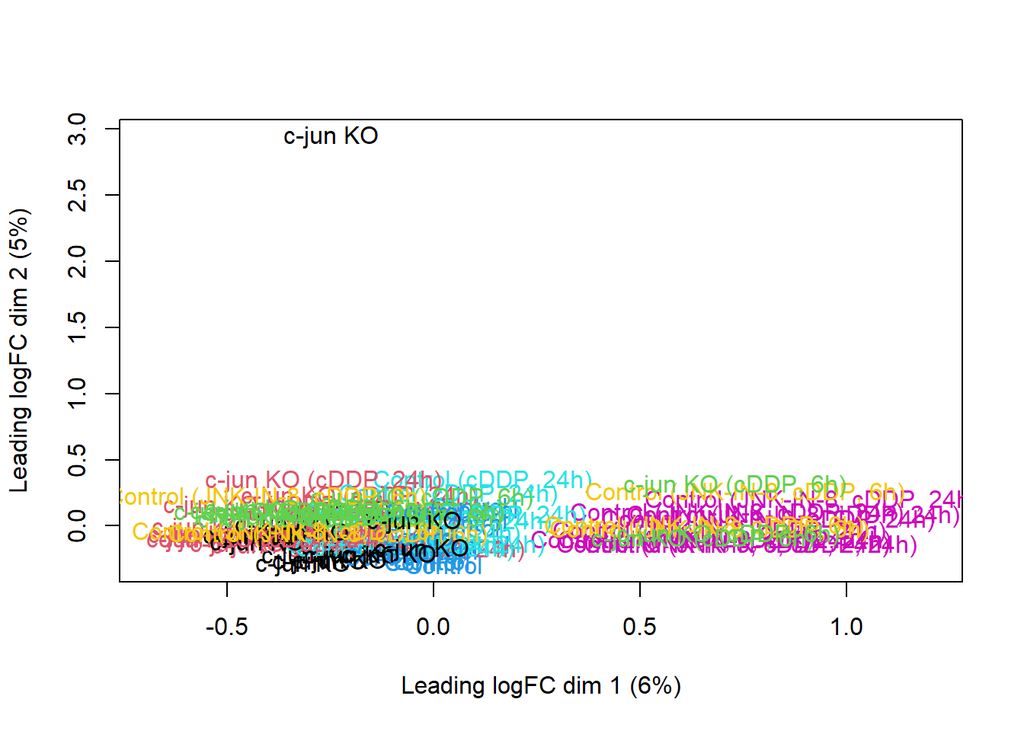

```r
#MDS plot
plotMDS(
  assay(se_batch),
  labels = colData(se_batch)$condition,
  col = as.numeric(
    factor(colData(se_batch)$condition)
  )
)
```

##11.Differential expression analysis

```r
expr <- assay(se_batch)
meta <- as.data.frame(colData(se_batch))

design <- model.matrix(~0+condition,data=meta)

colnames(design) <- c(
"c_junKO",
"c_jun_KO_cDDP24h",
"c_jun_KO_cDDP6h",
"Control",
"Control_cDDP24h",
"Control_JNKi24h",
"Control_JNKi6h")

fit <- lmFit(expr,design)
contrast.matrix <- makeContrasts(
Control_vs_KO = Control - Control_cDDP24h,
levels=design)

fit2 <- contrasts.fit(fit,contrast.matrix)

fit2 <- eBayes(fit2)

results <- topTable(
fit2,
number=Inf,
adjust.method="BH")
head(results)
```

```
##            logFC  AveExpr        t      P.Value    adj.P.Val        B
## Q92563 0.6063968 22.27225 9.995443 1.180308e-15 1.124362e-11 24.85928
## Q99523 0.7495119 22.39584 8.836808 2.098687e-13 9.996045e-10 19.97478
## O00468 0.5498947 22.08650 8.597752 6.137428e-13 1.948838e-09 18.96020
## Q93063 0.7023998 21.19178 8.341392 1.939356e-12 4.618577e-09 17.87154
## Q07973 0.8048853 21.64497 8.207360 3.537658e-12 6.739947e-09 17.30245
## P16144 0.4866794 25.25108 8.113734 5.382098e-12 8.544977e-09 16.90507
```

```r
summary(results)
```

```
##      logFC              AveExpr            t               P.Value
##  Min.   :-1.680544   Min.   :14.87   Min.   :-7.61887   Min.   :0.00000
##  1st Qu.:-0.118138   1st Qu.:19.49   1st Qu.:-1.10961   1st Qu.:0.06954
##  Median :-0.012150   Median :21.18   Median :-0.12489   Median :0.29671
##  Mean   :-0.003529   Mean   :21.21   Mean   :-0.02317   Mean   :0.36309
##  3rd Qu.: 0.099248   3rd Qu.:22.86   3rd Qu.: 0.97833   3rd Qu.:0.62213
##  Max.   : 1.961608   Max.   :30.44   Max.   : 9.99544   Max.   :0.99967
##    adj.P.Val            B
##  Min.   :0.0000   Min.   :-6.373
##  1st Qu.:0.2781   1st Qu.:-6.252
##  Median :0.5934   Median :-5.834
##  Mean   :0.5470   Mean   :-5.016
##  3rd Qu.:0.8295   3rd Qu.:-4.743
##  Max.   :0.9997   Max.   :24.859
```

```r
write_xlsx(data.frame(Protein_ID = rownames(results), results), "differential_exp_control_Control_cDDP24h.xlsx")
```

##12.Volcano plot

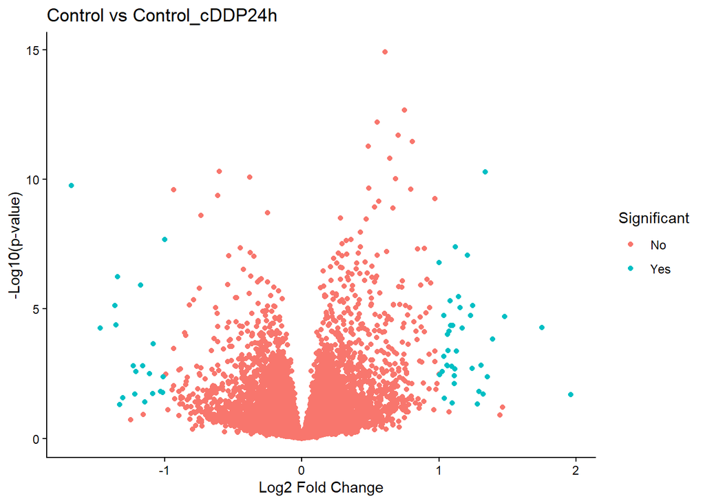

```r
results$Significant <- "No"

results$Significant[
results$P.Value<0.05 &
abs(results$logFC)>1] <- "Yes"

ggplot(results,
aes(logFC,
-log10(P.Value),
color=Significant))+
geom_point()+
labs(title = "Control vs Control_cDDP24h ",
       x = "Log2 Fold Change",
       y = "-Log10(p-value)")+
theme_classic()
```

```r
ggsave("Volcano_plot_control_vs_control_cDDP24h.png")
```

##13.Functional enrichment

```r
#Gene Ontology
ids <- bitr(
rownames(results),
fromType="UNIPROT",
toType="ENTREZID",
OrgDb=org.Hs.eg.db)
```

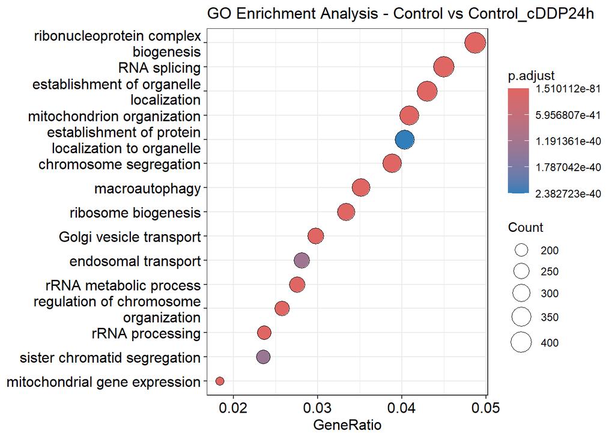

```r
ego <- enrichGO(
gene=ids$ENTREZID,
OrgDb=org.Hs.eg.db,
pvalueCutoff = 0.05,
ont="BP")

dotplot(ego, showCategory = 15)+
  ggtitle("GO Enrichment Analysis - Control vs Control_cDDP24h")
```

```r
ggsave("GO_plot_control_vs_control_cDDP24h.png")
#KEGG
ekegg <- enrichKEGG(
gene=ids$ENTREZID,
organism="hsa")
```

```
## Reading KEGG annotation online: "https://rest.kegg.jp/link/hsa/pathway"...
```

```
## Reading KEGG annotation online: "https://rest.kegg.jp/list/pathway/hsa"...
```

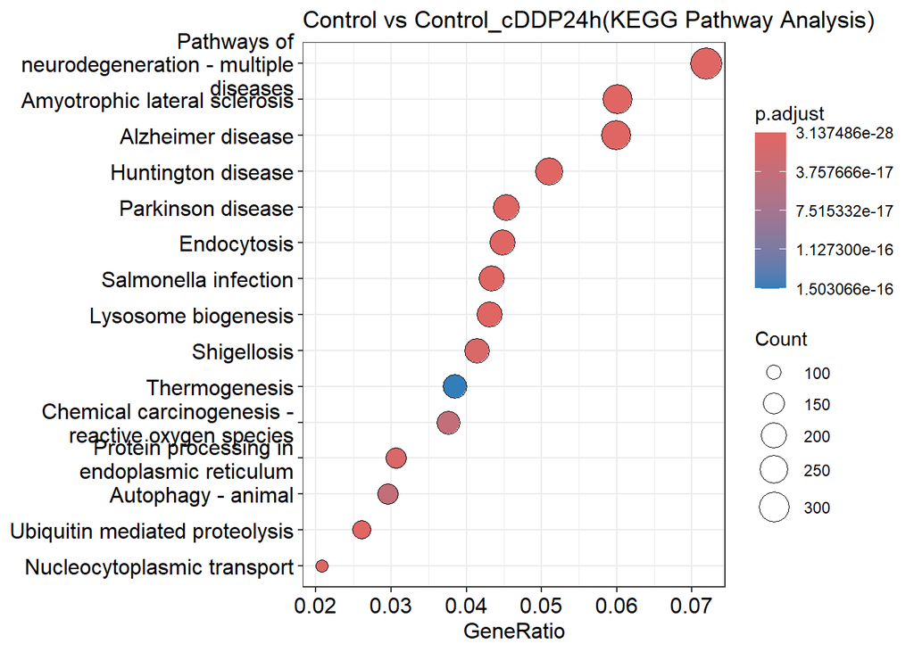

```r
dotplot(ekegg, showCategory = 15)+
  ggtitle("Control vs Control_cDDP24h(KEGG Pathway Analysis)")
```

```r
ggsave("KEGG_plot_control_vs_control_cDDP24h.png")
```